# Exploring age-length relationships for lionfish in Northeast Florida

Leonardo Feitosa and Cori Lopazanski

17 March 2022

# Introduction

Invasive species management requires a thorough understanding of life history characteristics, which can be used to model population dynamics and analyze effectiveness of various intervention strategies. Lionfish (*Pterois volitans/miles*) are an invasive species in the Caribbean, and have caused substantial harm to both the regional biological community and the people who rely on coral reefs for economic subsistence (Albins, 2015; Albins & Hixon, 2013). Since individual growth rates are often dependent on local environmental conditions, spatially-explicit estimates are necessary to better understand and manage lionfish invasions. Growth curves for this species have been generated for many locations throughout the Caribbean Sea (Akins et al., 2014; Rodríguez-Cortés, 2015). The paper we analyze in this project, by Eric G. Johnson and Mary Katherine Swenarton (2016), fills the knowledge gap on the individual-level growth patterns for a temperate population in Northeastern Florida.

Growth studies are also critical to understand how predator-prey interactions might be influenced by a rapid-growth invasive species such as the lionfish (Lorenzen, 2006). Johnson and Swenarton (2016) study the growth patterns and evaluate the population structure of *Pterois volitans/miles* through length-frequency data, applying a modified version of the von Bertalanffy Growth Function (VBGF) to include seasonality as an environmental parameter. In this paper, we recreate some of the analyses they performed, discuss the ecological importance of their results and point to methodological problems of the paper.

# Model Presentation

The von Bertalanffy growth function uses length as a proxy for age. Generally, the length of a fish increases as it gets older, and many fish species demonstrate rapid growth as juveniles that then decreases as they near their maximum size. For species which experience seasonal temperature variations, such as temperate lionfish, the seasonalized version of this length-age function is often most appropriate:

$$\begin{align}
\text{Seasonalized von } & \text{Bertalanffy growth equation:}
\newline
L_t & = L_\infty [1-e^{-(K(t-t_0))-S(t)+S(t_0)}] \\
\newline
S(t) &= \frac{CK}{2\pi} \cdot sin \pi(t-t_s)
\newline
S(t_0) &= \frac{CK}{2\pi} \cdot sin \pi(t_0-t_s)
\end{align}$$
Here, the length of a fish at a certain age ($L_t$) is a function of the Brody growth coefficient ($K$) and fluctuations in the growth rate depending on the seasonal growth patterns (described by $S(t)$ and $S(t_0)$). The intensity of these fluctuations is controlled by $C$, where $C = 0$ indicates no seasonality, and $C = 1$ indicates complete seasonality. A complete list of parameters and their descriptions are included in Table 1.

*Table 1. Description of variables and parameters for the seasonalized von Bertalanffy growth equation*

| Term | Estimate | Description |
| --- | --- | --- |
| $L_t$ | output variable (mm) | length of fish at age $t$ |
| $t$ | input variable (yr) | age $t$ |
| $L_\infty$ | 448 mm | asymptotic maximum length |
| $K$ | 0.47 yr$^{-1}$ | Brody growth coefficient |
| $t_0$ | 0 yr | theoretical time at which fish was length zero artificial constant set at zero for this paper) |
| $t_s$ | 0.71 yr | seasonal growth oscillation relative to $t_0$ |
| $t_w$ | not stated | winter point, time of slowest growth ($t_w = t_s + 0.5$) |
| $t_b$ | 0.41 yr | time of annual recruitment |
| $C$ | 0.61 | intensity of seasonal growth oscillation ($0 \leq C \leq 1$, where zero indicates no seasonality and one indicates complete seasonality) |

The authors used maximum likelihood to fit a predicted distribution to the length-frequency histograms from samples of collected lionfish. Length is a proxy for age, so the model estimates the proportion of fish of a given size in each age class. This function was then used to estimate the parameters for the best-fit model:

$$\begin{align}
L_t = 448 [1-e^{-0.47t+[\frac{0.061*0.47}{2\pi}]sin\pi(t-0.71)]-[\frac{0.61*0.47}{2\pi}sin\pi(0.71)]}]
\end{align}$$
This model assumes the following:

- All individuals are identical and experience the same environmental conditions
- Individual growth is only controlled by the passage of time and predicted seasonal oscillations (e.g. not affected by changes in conditions, predator presence, prey availability)
- The distribution of lengths in the population follows a normal distribution
- The population of lionfish has only four age classes
- Lionfish in this population reach an average maximum length of 448 mm
- The samples collected via spearfishing are reflective of the age-length distribution of the population
- Recruitment occurs in a single event on the same day each year

## Replication

In this section, we use the raw data provided in Johnson & Swenarton 2016 to generate and modify some of the figures presented in the paper.

First, we use the lengths of the lionfish samples to create three length-frequency histograms, which display the size structure of the collected samples each year (Figure 1).

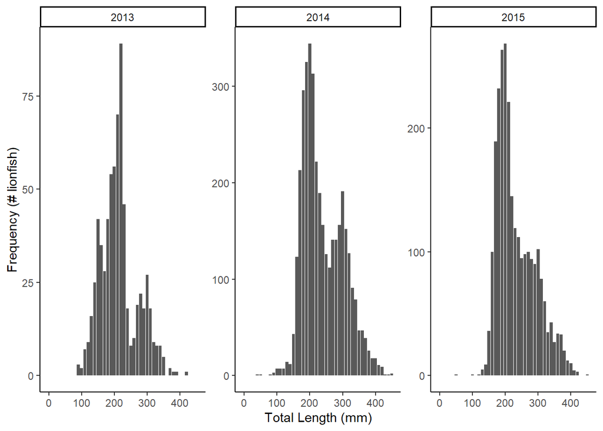

*Figure 1.* Length-frequency histograms for lionfish sampled across three years - 2013, 2014, and 2015. There were two sampling months for each year, in April and August. These were generated using the raw length data from all samples, as supplied in Johnson and Swenarton 2016.

Next, we use the parameters from their best-fit seasonalized von Bertalanffy growth model to recreate the growth curve, showing the relationship between age and length for lionfish. In addition, we also explore how different values of the seasonality coefficient affect model results (Figure 2).

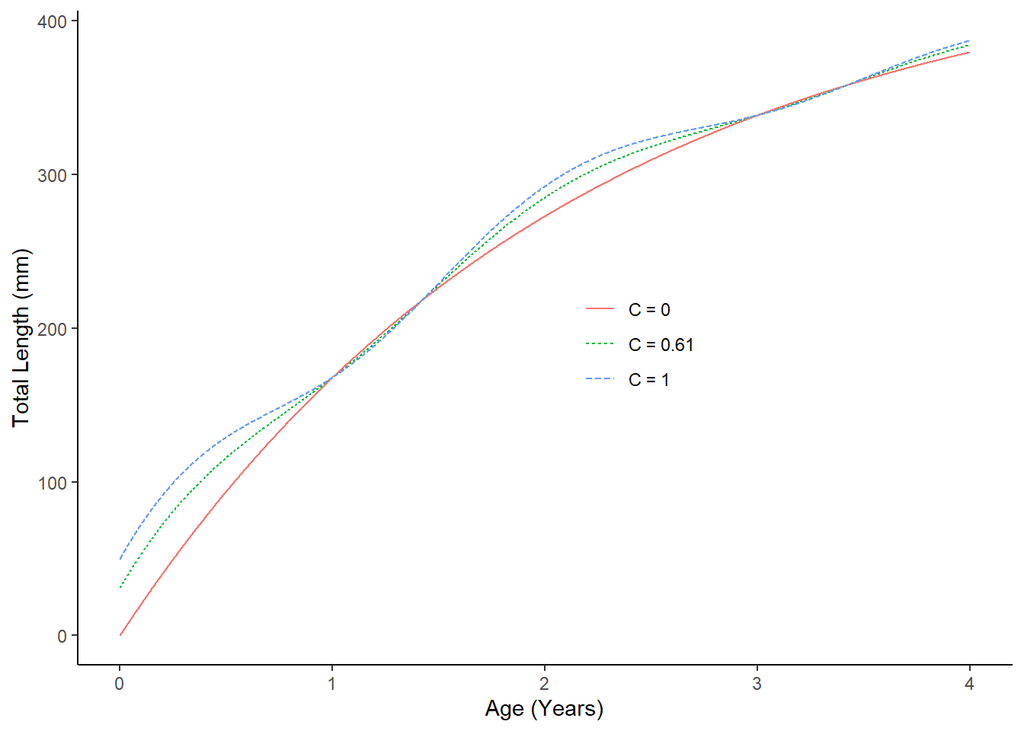

*Figure 2.* Estimated age-length relationship for lionfish in Northeast Florida using the seasonalized von-Bertalanffy growth function, comparing different values for the intensity of the seasonal growth oscillation. The best-fit model (green, dot-dash) shows moderate seasonality at C = 0.61. For comparison, the model was also evaluated with C = 0 (red, solid) indicating no seasonality, and C = 1 (blue, dashed) indicating complete seasonality.

Finally, we use the original length-frequency data from April 2013 to demonstrate how the snapshot age structure of the population would grow over time, assuming no individuals entered or exited the population (no births, immigration, deaths, or emigration) (Figure 3).

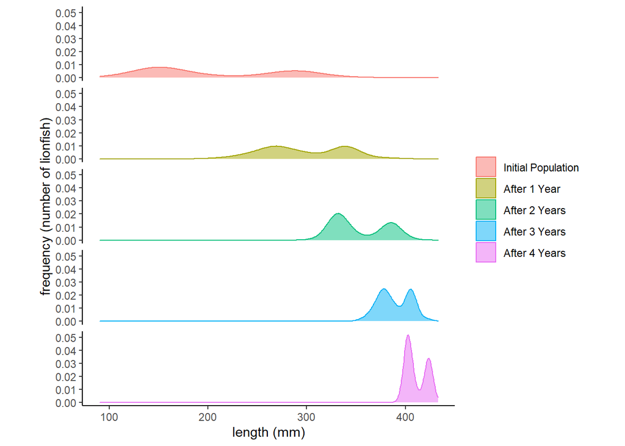

*Figure 3.* Shifting age and size structure of the lionfish population, as sampled in April 2013. This figure demonstrates growth of a single snapshot of individuals over four years, and does not account for any births, deaths, immigration, or emigration.

# Discussion

The main findings for this paper were the estimates for lionfish growth (Brody growth coefficient, K = 0.47), and population structure (the predicted distribution across age/size classes), which had not been previously examined for this population in Northeast Florida. Unlike other studies that did age and growth analyses for lionfish in the Caribbean Sea (Akins et al 2014; Rodríguez-Cortés, 2015), Johnson & Swenarton (2016) demonstrated that lionfish growth exhibits seasonality (C = 0.61), at least in this temperate region.The seasonal oscillations are likely correlated with temperature, given that growth is slower in winter months and faster in summer months, which is consistent with our understanding of the kinetics of many ecological processes. However, given the localized nature of this study, it is not possible to draw conclusions about its growth patterns for other areas where they have already well established populations. For example, the southern Caribbean is less affected by seasonality than Florida. If this model was applied to the lionfish populations of the southern Caribbean, it is likely that the sinusoidal growth pattern would be lower given the weaker local seasonality. Furthermore, Kimball et al (2004) studied the thermal tolerance of lionfish in the Atlantic and demonstrated that they die at 10ºC and can no longer feed at temperatures of 16ºC. Therefore, temperature could be considered a limiting factor for the invasion of areas further north of Florida where water temperatures might reach between 10 and 16ºC during the winter (Ruiz-Carus et al 2006). However, increases in sea surface temperatures associated with climate change could remove these limiting factors, facilitating future invasions further north of the USA.

Our main critique of this paper is that the proportion of lionfish in each age class in the samples is likely not representative of the population. Samples were caught by divers via spearfishing, which restricts the size range likely to be sampled. Small lionfish are very cryptic and would be both difficult to locate and spear effectively, and larger lionfish often move to deeper waters beyond the access of most divers. This means that the collected samples may inflate the proportion of the middle size classes. Therefore, this suggests that the model may be reasonable for estimating growth of the sampled size classes, but may not be appropriate for estimating growth of very small and very large size classes. Further, since the maximum asymptotic length ($L_\infty$) was specified based on the largest lionfish sampled, it is reasonable to suggest that the lionfish which travel to deeper waters may grow past this size.

# Citations

Akins, J. L., Morris Jr, J. A., & Green, S. J. (2014). In situ tagging technique for fishes provides insight into growth and movement of invasive lionfish. Ecology and Evolution, 4(19), 3768–3777. https://doi.org/10.1002/ece3.1171

Albins, M. A. (2015). Invasive Pacific lionfish Pterois volitans reduce abundance and species richness of native Bahamian coral-reef fishes. Marine Ecology Progress Series, 522, 231–243. https://doi.org/10.3354/meps11159

Albins, M. A., & Hixon, M. A. (2013). Worst case scenario: Potential long-term effects of invasive predatory lionfish (Pterois volitans) on Atlantic and Caribbean coral-reef communities. Environmental Biology of Fishes, 96(10), 1151–1157. https://doi.org/10.1007/s10641-011-9795-1

Johnson, E. G., & Swenarton, M. K. (2016). Age, growth and population structure of invasive lionfish (Pterois volitans/miles) in northeast Florida using a length-based, age-structured population model. PeerJ, 4, e2730. https://doi.org/10.7717/peerj.2730

Kimball, M. E., Miller, J. M., Whitfield, P. E., & Hare, J. A. (2004). Thermal tolerance and potential distribution of invasive lionfish (Pterois volitans/miles complex) on the east coast of the United States. Marine Ecology Progress Series, 283, 269-278. https://doi.org/10.3354/meps283269

Lorenzen K. 2006. Population management in fisheries enhancement: gaining key information from release experiments through use of a size-dependent mortality model. Fisheries Research 80:19-27. https://doi.org/10.1016/j.fishres.2006.03.010

Rodríguez-Cortés, K. D. (2015). Growth and mortality of red lionfish, Pterois volitans (Actinopterygii: Scorpaeniformes: Scorpaenidae), in the Parque Nacional Arrecife Alacranes, southern Gulf of Mexico, as determined by size-frequency analysis. Acta Ichthyologica et Piscatoria, 45(2), 175–179. https://doi.org/10.3750/AIP2015.45.2.07

Ruiz-Carus, R., Matheson Jr, R. E., Roberts Jr, D. E., & Whitfield, P. E. (2006). The western Pacific red lionfish, Pterois volitans (Scorpaenidae), in Florida: Evidence for reproduction and parasitism in the first exotic marine fish established in state waters. Biological Conservation, 128(3), 384-390. https://doi.org/10.1016/j.biocon.2005.10.012